**Discrete Fourier Transformation (DFT)**

By Prof. Seungchul Lee  
http://iai.postech.ac.kr/  
Industrial AI Lab at POSTECH

Table of Contents

# 1. Fourier Series

## 1.1. Delta Dirac Function

$$ \sum_{n = 1,2,3,\cdots}\cos(n \theta) = \cos \theta + \cos 2\theta + \cos 3\theta + \cdots $$

```python
import numpy as np
import matplotlib.pyplot as plt
%matplotlib inline

import IPython.display as ipd
import librosa.display
from mpl_toolkits.mplot3d import Axes3D

from scipy import signal
from scipy.fftpack import fft, ifft, fftshift
```

https://docs.scipy.org/doc/scipy/reference/signal.html

https://docs.scipy.org/doc/scipy/reference/fftpack.html

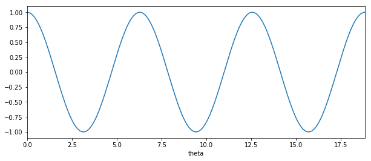

```python
theta = np.linspace(0, 6*np.pi, 2**8)
x1 = np.cos(theta)

# plot
plt.figure(figsize=(10, 4))
plt.plot(theta, x1)
plt.ylim([-1.1, 1.1])
plt.xlim([np.min(theta), np.max(theta)])
plt.xlabel('theta')
plt.show()
```

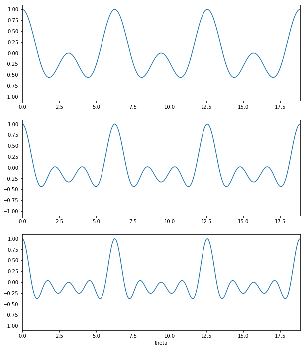

```python
x2 = x1 + np.cos(2*theta)
x3 = x2 + np.cos(3*theta)
x4 = x3 + np.cos(4*theta)

# plot
plt.figure(figsize=(10,12))
plt.subplot(3,1,1)
plt.plot(theta, x2/2)
plt.xlim([np.min(theta), np.max(theta)])
plt.ylim([-1.1, 1.1])

plt.subplot(3,1,2)
plt.plot(theta, x3/3)
plt.xlim([np.min(theta), np.max(theta)])
plt.ylim([-1.1, 1.1])

plt.subplot(3,1,3)
plt.plot(theta, x4/4)
plt.xlim([np.min(theta), np.max(theta)])
plt.ylim([-1.1, 1.1])
plt.xlabel('theta')
plt.show()
```

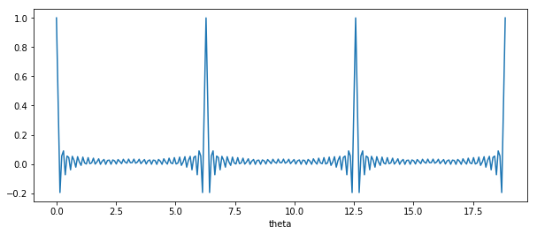

```python
x = np.zeros(theta.shape)

N = 30
for n in range(N):
    x = x + np.cos(n*theta)

# plot
plt.figure(figsize=(10, 4))
plt.plot(theta, x/N)
plt.xlabel('theta')
plt.show()
```

## 1.2. Square Wave

$$ \sum_{n = 1,3,5,\cdots}\frac{4}{\pi n} \sin (n\theta) = \frac{4}{\pi} \sin \theta + \frac{4}{3 \pi} \sin 3\theta + \frac{4}{5 \pi} \sin 5\theta + \cdots$$

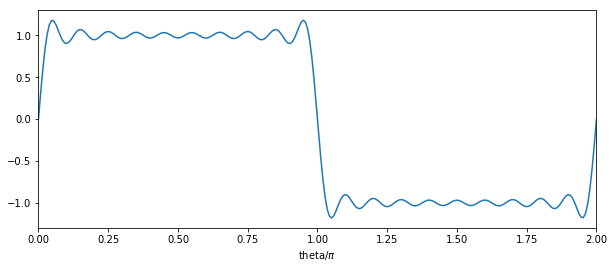

```python
N = 2**8
theta = np.linspace(0, 2*np.pi, N)
x = np.zeros(theta.shape)

for n in range(1, 20, 2):
    x = x + 4/(np.pi*n)*np.sin(n*theta)

# plot
plt.figure(figsize=(10, 4))
plt.plot(theta/np.pi, x)
plt.xlabel('theta/$\pi$')
plt.xlim([0, 2])
plt.show()
```

## 1.3. How to Decompose a Signal into Fundamental Harmonic Sinusoids

- Signal representation by harmonic sinusoids
- Questions
  - how to decompose it to harmonic sinusoids
  - how to find the coefficients of harmonic sinusoids
  - how to find the frequency components
- DFT or FFT can do such a job !!!

[figure not shown]

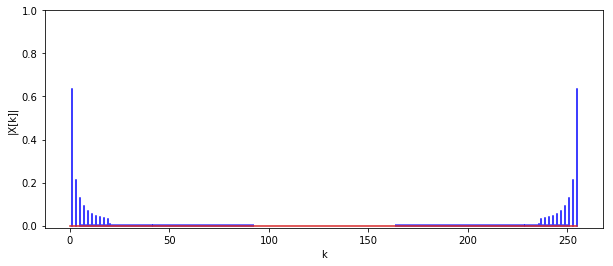

```python
xt = fft(x, N)/N

# plot
plt.figure(figsize=(10, 4))
plt.stem(np.arange(0, N), np.abs(xt), 'b', 'w')
plt.ylim([-0.01,1])
plt.xlabel('k')
plt.ylabel('|X[k]|')
plt.show()
```

$$ \sum_{n = 1,3,5,\cdots}\frac{4}{\pi n} \sin (n\theta) = \frac{4}{\pi} \sin \theta + \frac{4}{3 \pi} \sin 3\theta + \frac{4}{5 \pi} \sin 5\theta + \cdots$$

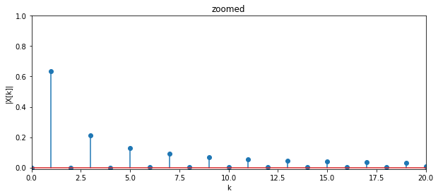

```python
# plot
plt.figure(figsize=(10, 4))
plt.stem(np.arange(0, N), np.abs(xt))
plt.ylim([-0.01,1])
plt.xlabel('k')
plt.ylabel('|X[k]|')
plt.title('zoomed')
plt.xlim([0, 20])
plt.show()
```

# 2. Signal Representation (optional)

## 2.1. Basis

A **basis** $\{b_k\}$ for a vector space $V$ is a collection of vectors from $V$ that linearly independent and span $V$

- Basis matrix: stack the basis vectors $b_k$ as columns

$$ B \,\,=\,\, \left[b_0 \mid b_1 \mid b_2 \mid \cdots \mid b_{N-1} \right]$$

- Using this matrix $B$, we can now write a linear combination of basis elements as the matrix/vector product

$$ \begin{align*} x & = \, B\, a\, =\, a_0 b_0 + a_1 b_1 +\, \cdots\, + a_{N-1} b_{N-1} \, =\, \sum_{k=0}^{N-1} a_k b_k \,\\ &=\, \left[b_0 \mid b_1 \mid b_2 \mid \cdots \mid b_{N-1} \right]\begin{bmatrix} a_0\\ a_1\\ \vdots\\ a_{N-1} \end{bmatrix} \end{align*}$$

### 2.1.1. Orthonormal Basis

- An **orthogonal basis** $\{b_k\}_{k=0}^{N-1}$ for a vector space $V$ is a basis whose elements are mutually orthogonal

$$\langle b_k,b_l\rangle \, =\, 0\, \quad k\, \neq\, l$$

- An **orthonormal basis**$\{b_k\}_{k=0}^{N-1}$ for a vector space $V$ is a basis whose elements are mutually orthogonal and normalized (in the 2-norm)

$$\begin{align*} \langle b_k,b_l\rangle \, &=\, 0\, \quad k\, \neq\, l, \quad \text{ and}\\ \| b_k\|_2 \, &= \, 1 \quad \forall k \end{align*}$$

- $B$ is a unitrary matrix

$$B^H B = I \implies B^{-1} = B^H, \qquad \text{where } B^H \text{ is complex conjugate transpose}$$

$$ \begin{align*} B^H B = \begin{bmatrix} b_0^H\\ b_1^H\\ \vdots\\ b_{N-1}^H \end{bmatrix} \left[b_0 \mid b_1 \mid b_2 \mid \cdots \mid b_{N-1} \right] \end{align*} = \begin{bmatrix} 1 & \\ & 1\\ & & \ddots\\ & & & 1 \end{bmatrix} $$

### 2.1.2. Signal Representation by Orthonormal Basis

Signal representation for any signal $x$

$$ \begin{align*} x &= B\alpha = \sum_{k=0}^{N-1}\alpha_kb_k, &\text{(synthesis)}\\ \\ \alpha &= B^Hx \qquad \text{or} \qquad \alpha_k = \langle x,b_k \rangle, &\text{(analysis)} \end{align*}$$

- **Synthesis**: Build up the signal $x$ as a linear combination of the basis elements $b_k$ weighted by the weights $\alpha_k$
- **Analysis**: Compute the weights $\alpha_k$ such that the synthesis produces $x$; the weight $\alpha_k$ measures the similarity between $x$ and the basis element $b_k$

## 2.2. Harmonic Sinusoids are an Orthonormal Basis

Stack $N$ normalized harmonic sinusoid $\{s_k\}_{k=0}^{N-1}$ as columns into an $N\times N$ complex orthonormal basis matrix

$$ \begin{align*} S = \left[s_0 \mid s_1 \mid \cdots \mid s_{N-1} \right] \quad \text{where}\quad s_k[n] = \frac{1}{\sqrt{N}}e^{j\frac{2\pi}{N}kn} \end{align*} $$

$$S^H S = I \implies \langle s_k,s_l\rangle \, =\, 0 \quad k\, \neq l,\quad \text{and}\quad \lVert s_k \rVert_2\, =\, 1$$

# 3. Discrete Fourier Tranformation (DFT)

**DFT**

- It finds the “frequency contents” at frequency $k$
- It measures the similarity between $x$ and the harmonic sinusoid $s_k$

$$ \begin{align*} X\, &=\, S^Hx \\ X[k]\, &=\, \langle x,s_k\rangle\, =\, \sum \limits_{n=0}^{N-1} x[n]\,\frac{e^{-j\frac{2 \pi}{N}kn}}{\sqrt{N}} \end{align*}$$

**Inverse DFT**

- It is returning to time domain
- It builds up the signal $x$ as a linear combination of $s_k$ weighted by the $X[k]$

$$ \begin{align*} x\, &=\, SX \\ x[n]\, &=\, \sum \limits_{k=0}^{N-1}X[k]\, \frac{e^{j\frac{2 \pi}{N}kn}}{\sqrt{N}} \end{align*} $$

**Unnormalized DFT**

- Normalized forward and inverse DFT

$$ \begin{align*}X[k] &= \sum \limits_{n=0}^{N-1} x[n]\,\frac{e^{-j\frac{2 \pi}{N}kn}}{\sqrt{N}}\\ x[n] &= \sum \limits_{k=0}^{N-1}X[k]\, \frac{e^{j\frac{2 \pi}{N}kn}}{\sqrt{N}} \end{align*} $$

- Unnormalized forward and inverse DFT

$$ \begin{align*}X_u[k] &= \sum \limits_{n=0}^{N-1} x[n]\,e^{-j\frac{2 \pi}{N}kn}\\ x[n] &= \frac{1}{N}\sum \limits_{k=0}^{N-1}X[k]\, e^{j\frac{2 \pi}{N}kn} \end{align*} $$

## 3.1. Fast Fourier Transformation (FFT)

- FFT algorithms are so commonly employed to compute DFT that the term 'FFT' is often used to mean 'DFT'
  - The FFT has been called the "most important computational algorithm of our generation"
  - It uses the dynamic programming algorithm (or divide and conquer) to efficiently compute DFT.
- DFT refers to a mathematical transformation or function, whereas 'FFT' refers to a specific family of algorithms for computing DFTs.
  - use `fft` command to compute `dft`
  - `fft` (computationally efficient)
- We will use the embedded `fft` function without going too much into detail.

[figure not shown]

**Example**

$$x[n] = e^{j\frac{2\pi}{8}n}$$

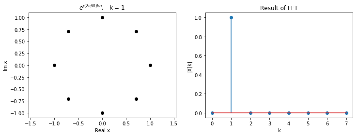

```python
k = 1   # index for frequency

N = 8
n = np.arange(0, N) # sampling period

x = np.exp(1j*2*np.pi/N*k*n) # harmonic complex exponential
xt = fft(x)/N

# plot
plt.figure(figsize=(12,4))
plt.subplot(1,2,1)
plt.plot(np.real(x), np.imag(x), 'ko')
plt.axis('equal')
plt.xlabel('Real x')
plt.ylabel('Im x')
plt.title('$e^{j(2\pi/N) kn}$,   k = 1')

plt.subplot(1,2,2)
plt.stem(n, np.abs(xt))
plt.xlabel('k')
plt.ylabel('|X[k]|')
plt.title('Result of FFT')
plt.show()
```

$$x[n] = \cos \left(\frac{2\pi}{8}n \right)$$

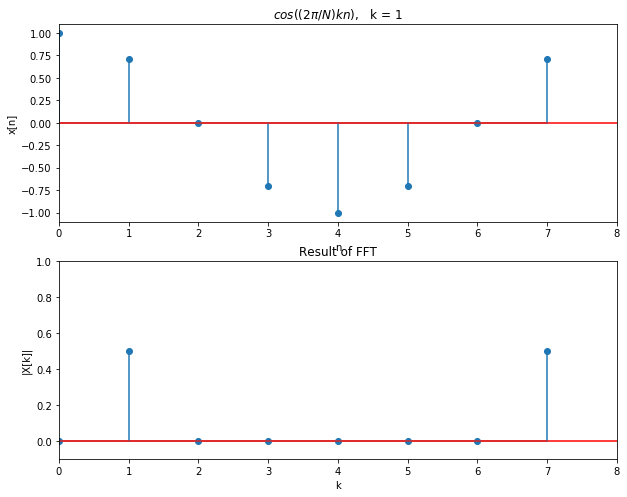

```python
k = 1 # index for frequency

N = 8
n = np.arange(0, N) # sampling period

x = np.cos(2*np.pi/N*k*n) # harmonic complex exponential
xt = fft(x)/N

# plot
plt.figure(figsize=(10,8))
plt.subplot(2,1,1)
plt.stem(n, np.real(x))
plt.xlim([0, 8])
plt.hlines(0,0,8, 'r')
plt.xlabel('n')
plt.ylabel('x[n]')
plt.title('$cos((2\pi/N) kn)$,   k = 1')

plt.subplot(2,1,2)
plt.stem(n, np.abs(xt))
plt.xlim([0, 8])
plt.ylim([-0.1, 1])
plt.hlines(0,0,8, 'r')
plt.xlabel('k')
plt.ylabel('|X[k]|')
plt.title('Result of FFT')
plt.show()
```

- Remember $$ \cos \omega t = \frac{e^{i \omega t} + e^{-i \omega t}}{2}$$

[figure not shown]

## 3.2. DFT Frequencies

- $X[k]$ measures the similarity between the time signal $x[n]$ and the harmonic sinusoid $s_k[n]$
- $X[k]$ measures the "frequency content" of $x[n]$ at frequency

$$\omega_k = \frac{2\pi}{N} k$$

- Typical interval 1: $0 \leq k \leq N-1$ corresponds to frequencies $\omega_k$ in the interval $0 \leq \omega \leq 2\pi$
- Typical interval 2: $-\frac{N}{2} \leq k \leq \frac{N}{2} -1$ corresponds to frequencies $\omega_k$ in the interval $-\pi \leq \omega \leq \pi$

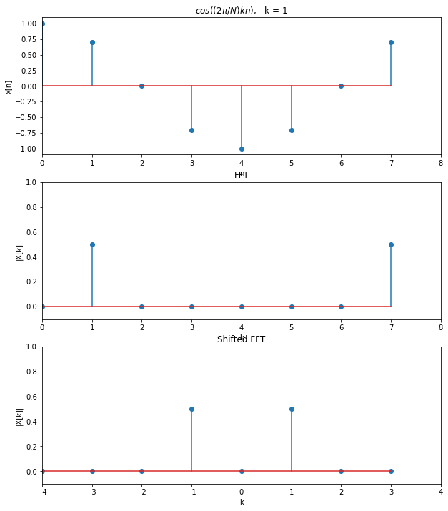

```python
k = 1 # index for frequency

N = 8
n = np.arange(0, N) # sampling period
x = np.cos(2*np.pi/N*k*n) # harmonic complex exponential
xt = fft(x)/N
xtshift = fftshift(xt)

kr = np.hstack([np.arange(0,N/2),np.arange(-N/2,0)])
ks = fftshift(kr)

# plot
plt.figure(figsize=(10,12))
plt.subplot(3,1,1)
plt.stem(n, np.real(x))
plt.xlim([0, 8])
plt.xlabel('n')
plt.ylabel('x[n]')
plt.title('$cos((2\pi/N) kn)$,   k = 1')

plt.subplot(3,1,2)
plt.stem(n, np.abs(xt))
plt.xlim([0, 8])
plt.ylim([-0.1, 1])
plt.xlabel('k')
plt.ylabel('|X[k]|')
plt.title('FFT')

plt.subplot(3,1,3)
plt.stem(ks, np.abs(xtshift))
plt.xlim([-4, 4])
plt.ylim([-0.1, 1])
plt.xlabel('k')
plt.ylabel('|X[k]|')
plt.title('Shifted FFT')
plt.show()
```

[figure not shown]

# 4. Filtering in Frequency Domain

**DFT pair**

$$x[n] \longleftrightarrow X[k]$$

**DFT and Convolution**

- Convolution in the time domain $=$ multiplication in the frequency domain

$$ \begin{align*} Y[k] &= H[k]X[k] \\ h[n]\otimes x[n] &\longleftrightarrow H[k]X[k] \\ y[n] &= \text{IDFT}(Y[k]) \end{align*} $$

[figure not shown]

## 4.1. Filters

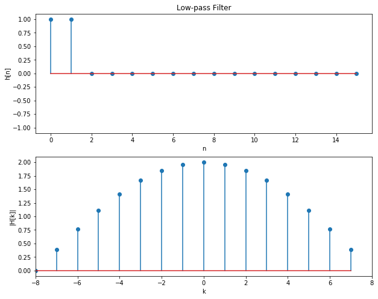

```python
# low-pass filter

N = 16
n = np.arange(0, N)

h = np.zeros(n.shape)
h[0] = 1
h[1] = 1

kr = np.hstack([np.arange(0,N/2),np.arange(-N/2,0)])
ks = fftshift(kr)

ht = fft(h, N)
htshift = fftshift(ht)

# plot
plt.figure(figsize=(10,8))
plt.subplot(2,1,1)
plt.stem(n, h)
plt.ylim([-1.1,1.1])
plt.xlabel('n')
plt.ylabel('h[n]')
plt.title('Low-pass Filter')

plt.subplot(2,1,2)
plt.stem(ks, np.abs(htshift))
plt.xlim([-N/2, N/2])
plt.xlabel('k')
plt.ylabel('|H[k]|')
plt.show()
```

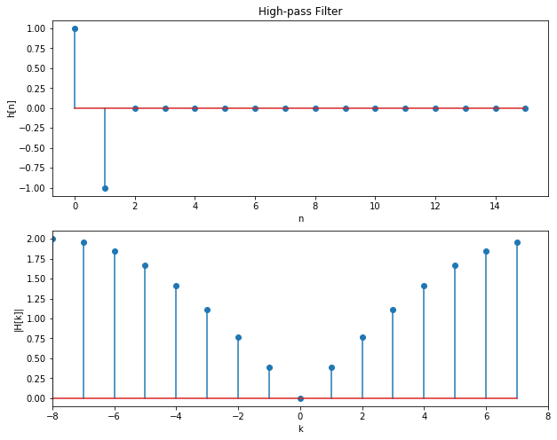

```python
# high-pass filter

N = 16
n = np.arange(0, N)

h = np.zeros(n.shape)
h[0] = 1
h[1] = -1

kr = np.hstack([np.arange(0,N/2),np.arange(-N/2,0)])
ks = fftshift(kr)

ht = fft(h, N)
htshift = fftshift(ht)

# plot
plt.figure(figsize=(10,8))
plt.subplot(2,1,1)
plt.stem(n, h)
plt.xlabel('n')
plt.ylabel('h[n]')
plt.title('High-pass Filter')

plt.subplot(2,1,2)
plt.stem(ks, np.abs(htshift))
plt.xlim([-N/2, N/2])
plt.xlabel('k')
plt.ylabel('|H[k]|')
plt.show()
```

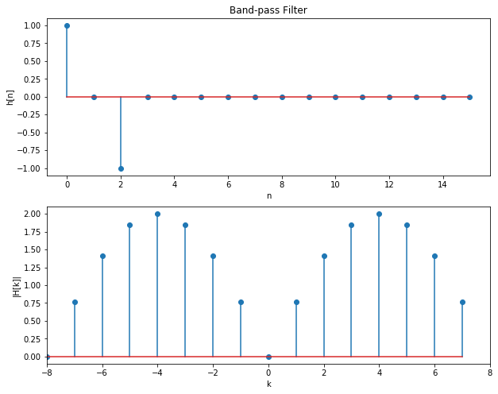

```python
# band-pass filter

N = 16
n = np.arange(0, N)

h = np.zeros(n.shape)
h[0] = 1
h[1] = 0
h[2] = -1

kr = np.hstack([np.arange(0,N/2),np.arange(-N/2,0)])
ks = fftshift(kr)

ht = fft(h, N)
htshift = fftshift(ht)

# plot
plt.figure(figsize=(10,8))
plt.subplot(2,1,1)
plt.stem(n, h)
plt.xlabel('n')
plt.ylabel('h[n]')
plt.title('Band-pass Filter')

plt.subplot(2,1,2)
plt.stem(ks, np.abs(htshift))
plt.xlim([-N/2, N/2])
plt.xlabel('k')
plt.ylabel('|H[k]|')
plt.show()
```

## 4.2. FFT and Convolution

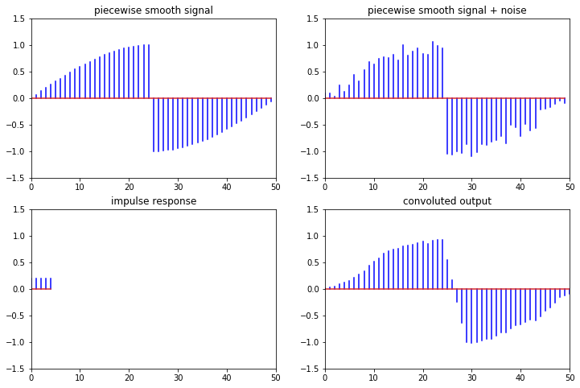

```python
# piecewise smooth signal

N = 50
n = np.arange(0, N)

V = np.hstack([np.ones([1, np.int(N/2)]), -np.ones([1, np.int(N/2)])])
x = np.sin(np.pi/N*n)*V
xn = x + 0.1*np.random.randn(1, N)

# construct moving average filter impulse response of length M
M = 5
h = np.zeros([1, M])
h[0, 0:M] = 1/M

# convolve noisy signal with impulse response
y = signal.convolve(xn, h)

# plot
plt.figure(figsize=(12,8))
plt.subplot(2,2,1)
plt.stem(x.T, 'b', 'w')
plt.xlim([0, N])
plt.ylim([-1.5, 1.5])
plt.title('piecewise smooth signal')

plt.subplot(2,2,2)
plt.stem(xn.T, 'b', 'w')
plt.xlim([0, N])
plt.ylim([-1.5, 1.5])
plt.title('piecewise smooth signal + noise')

plt.subplot(2,2,3)
plt.stem(h.T, 'b', 'w')
plt.xlim([0, N])
plt.ylim([-1.5, 1.5])
plt.title('impulse response')

plt.subplot(2,2,4)
plt.stem(y.T, 'b', 'w')
plt.xlim([0, N])
plt.ylim([-1.5, 1.5])
plt.title('convoluted output')
plt.show()
```

$$ \begin{align*} Y[k] &= H[k]X[k] \\ h[n]\otimes x[n] &\longleftrightarrow H[k]X[k] \\ y[n] &= \text{IDFT}(Y[k]) \end{align*} $$

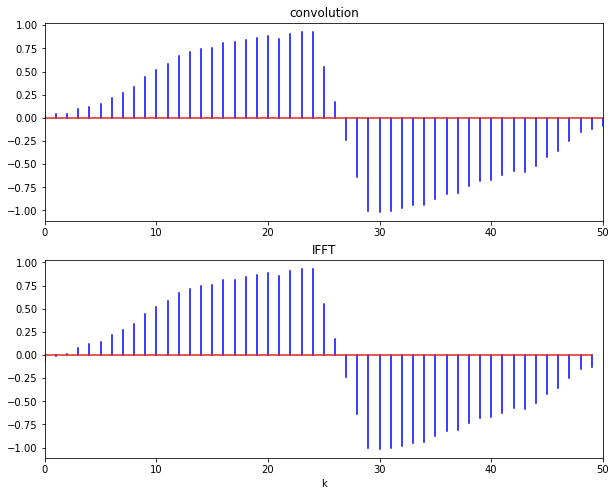

```python
k = np.arange(0, N)

ht = fft(h,N)
xnt = fft(xn,N)
xf = ifft(ht*xnt,N)

# plot
plt.figure(figsize=(10,8))
plt.subplot(2,1,1)
plt.stem(y.T, 'b', 'w')
plt.xlim([0, N])
plt.title('convolution')

plt.subplot(2,1,2)
plt.stem(k, np.real(xf.T), 'b', 'w')
plt.xlim([0, N])
plt.xlabel('k')
plt.title('IFFT')
plt.show()
```

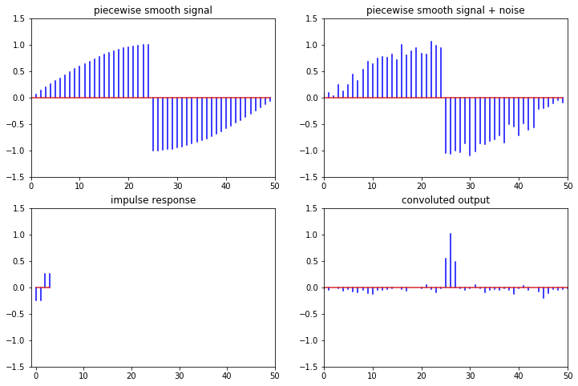

```python
# haar wavelet edge detector

M = 4
h = np.zeros([1, M])
h[0, 0:2] = -1/M
h[0, 2:4] = 1/M

# convolve noisy signal with impulse response
y = signal.convolve(xn, h)

# plot
plt.figure(figsize=(12,8))
plt.subplot(2,2,1)
plt.stem(x.T, 'b', 'w')
plt.xlim([0, N])
plt.ylim([-1.5, 1.5])
plt.title('piecewise smooth signal')

plt.subplot(2,2,2)
plt.stem(xn.T, 'b', 'w')
plt.xlim([0, N])
plt.ylim([-1.5, 1.5])
plt.title('piecewise smooth signal + noise')

plt.subplot(2,2,3)
plt.stem(h.T, 'b', 'w')
plt.xlim([-1, N])
plt.ylim([-1.5, 1.5])
plt.title('impulse response')

plt.subplot(2,2,4)
plt.stem(y.T, 'b', 'w')
plt.xlim([0, N])
plt.ylim([-1.5, 1.5])
plt.title('convoluted output')
plt.show()
```

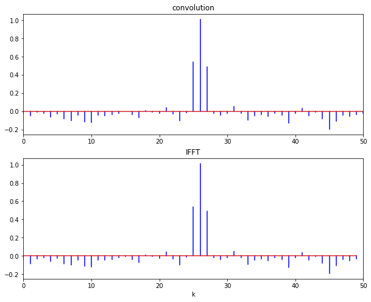

```python
k = np.arange(0, N)

ht = fft(h, N)
xnt = fft(xn, N)
xf = ifft(ht*xnt)

# plot
plt.figure(figsize=(10,8))
plt.subplot(2,1,1)
plt.stem(y.T, 'b', 'w')
plt.xlim([0, N])
plt.title('convolution')

plt.subplot(2,1,2)
plt.stem(k, np.real(xf.T), 'b', 'w')
plt.xlim([0, N])
plt.xlabel('k')
plt.title('IFFT')
plt.show()
```

**With Audio**

```python
x, sr1 = librosa.load('./data_files/violin_origional.wav')

x = x/np.max(x) # normalize

ipd.Audio(x, rate=sr1) # play a wave file with sampling rate sr
```

[interactive chart not shown]

```python
# impulse response in a closed room (by gunshot)

h, sr2 = librosa.load('./data_files/gunshot.wav')

ipd.Audio('./data_files/gunshot.wav', rate=sr2) # play a wave file with sampling rate sr
```

[interactive chart not shown]

```python
N = max(len(x),len(h))

ht = fft(h, N)
xt = fft(x, N)
xf = ifft(ht*xt, N)

y = np.real(xf)
y = y/max(y)

ipd.Audio(y, rate=sr1)
```

[interactive chart not shown]

# 5. Frequency in Images

```python
import cv2
from skimage.util import random_noise
from scipy.fftpack import fft, ifft, fftshift, ifftshift, fft2, ifft2
```

[figure not shown]

```python
# fft with an image

cm = cv2.imread('.\image_files\cameraman.png', 0)

CMs = fftshift(fft2(cm))

CMr = ifftshift(CMs)
cmr = ifft2(CMr)

# plot
plt.figure(figsize = (12,12))
plt.subplot(2,2,1)
plt.title('Original')
plt.imshow(cm, cmap = 'gray')
plt.axis('off')

plt.subplot(2,2,2)
plt.title('FFT')
plt.imshow(np.log(1+np.absolute(CMs)), cmap = 'gray')
plt.axis('off')

plt.subplot(2,2,3)
plt.title('Recovered')
plt.imshow(np.real(cmr), cmap = 'gray')
plt.axis('off')
plt.show()
```

# 5.1. Gaussian Filter

$$e^{\left(-\alpha_1 x^2 - \alpha_2 y^2\right)}$$

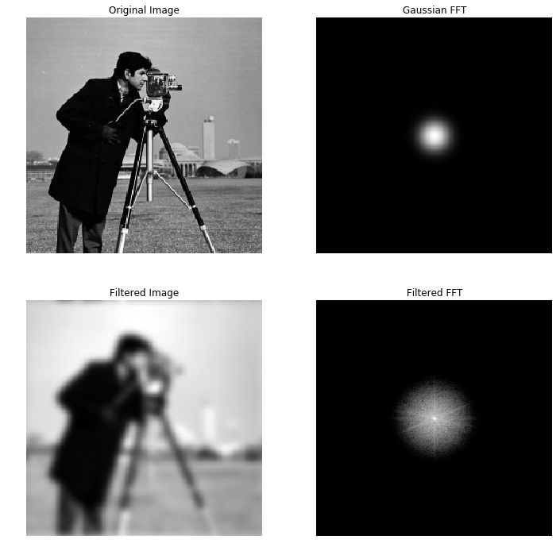

```python
N = cm.shape[0]

x, y = np.meshgrid(np.arange(-int(N/2), int(N/2), 1), np.arange(-int(N/2), int(N/2), 1))
a1 = 0.005
a2 = 0.005
Z = np.exp(- a1*x**2 - a2*y**2) # Gaussian in frequency domain

CMFs = CMs*Z

CMFr = ifftshift(CMFs)
cmfr = ifft2(CMFr)

# plot
plt.figure(figsize = (12,12))
plt.subplot(2,2,1)
plt.title('Original Image')
plt.imshow(cm, cmap = 'gray')
plt.axis('off')

plt.subplot(2,2,2)
plt.title('Gaussian FFT')
plt.imshow(np.log(1+np.absolute(Z)), cmap = 'gray')
plt.axis('off')

plt.subplot(2,2,3)
plt.title('Filtered Image')
plt.imshow(np.real(cmfr), cmap = 'gray')
plt.axis('off')

plt.subplot(2,2,4)
plt.title('Filtered FFT')
plt.imshow(np.log(1+np.absolute(CMFs)), cmap = 'gray')
plt.axis('off')
plt.show()
```

**Finding Abraham Lincoln**

- Gala Contemplating the Mediterranean Sea Which at Twenty Meters Becomes the Portrait of Abraham Lincoln
- from http://thedali.org/exhibit/gala-contemplating-mediterranean-sea/

[figure not shown]

```python
imgray = cv2.imread('.\image_files\Dali.jpg', 0) # gray image

# plot
plt.figure(figsize = (6,6))
plt.title('Grayed Painting')
plt.imshow(imgray, cmap = 'gray')
plt.axis('off')
plt.show()
```

[figure not shown]

```python
IM = fft2(imgray)
IMs = fftshift(IM)

# Gaussian

N = IMs.shape[0]
M = IMs.shape[1]
x, y = np.meshgrid(np.arange(-int(M/2), int(M/2), 1), np.arange(-int(N/2), int(N/2), 1))
a1 = 0.005
a2 = 0.005
Z = np.exp(- a1*x**2 - a2*y**2)

IMFs = IMs*Z

IMFr = ifftshift(IMFs)
imfr = ifft2(IMFr)

# plot
plt.figure(figsize = (12,6))
plt.subplot(1,2,1)
plt.title('Grayed Painting')
plt.imshow(imgray, cmap = 'gray')
plt.axis('off')

plt.subplot(1,2,2)
plt.title('Blurred Image')
plt.imshow(np.real(imfr), cmap = 'gray')
plt.axis('off')
plt.show()
```

## 5.2. Notch Filter

- band-stop filter
- periodic noise reduction

[figure not shown]

```python
# load a test image (with patterned noises)

im = cv2.imread('.\image_files\ClownOrig.jpg', 0)

# plot
plt.figure(figsize = (6,6))
plt.imshow(im, cmap = 'gray')
plt.axis('off')
plt.show()
```

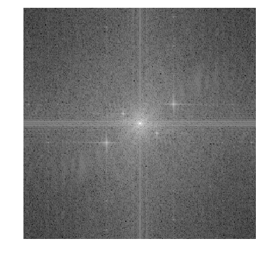

```python
# transform to Fourier Domain

IM = fft2(im)
IMs = fftshift(IM)

# plot
plt.figure(figsize = (6,6))
plt.imshow(np.log(1+np.absolute(IMs)), cmap = 'gray')
plt.axis('off')
plt.show()
```

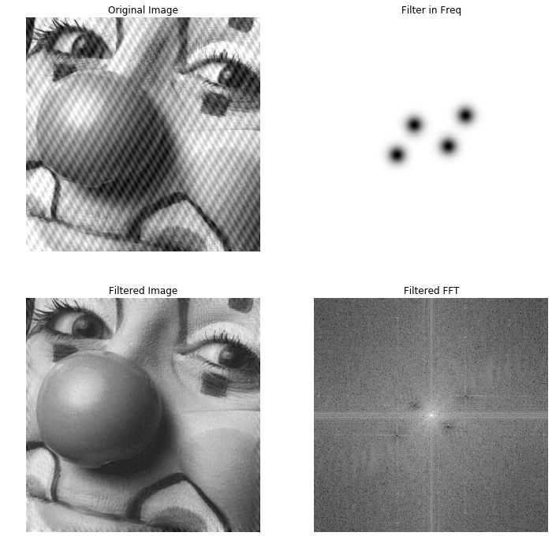

```python
# run it in Python for interactive demo

N = IMs.shape[0]
x, y = np.meshgrid(np.arange(N), np.arange(N))

# notch filter generation (need to understand)

a1 = 0.008
a2 = 0.008

NF1 = 1 - np.exp(-a1*(x-190)**2 - a2*(y-123)**2) # Gaussian
NF2 = 1 - np.exp(-a1*(x-104)**2 - a2*(y-172)**2) # Gaussian
NF3 = 1 - np.exp(-a1*(x-126)**2 - a2*(y-135)**2) # Gaussian
NF4 = 1 - np.exp(-a1*(x-168)**2 - a2*(y-161)**2) # Gaussian

Z = NF1*NF2*NF3*NF4
IMFs = IMs*Z

IMFr = ifftshift(IMFs)
imfr = ifft2(IMFr)

# plot
plt.figure(figsize = (12,12))
plt.subplot(2,2,1)
plt.title('Original Image')
plt.imshow(im, cmap = 'gray')
plt.axis('off')

plt.subplot(2,2,2)
plt.title('Filter in Freq')
plt.imshow(np.log(1+np.absolute(Z)), cmap = 'gray')
plt.axis('off')

plt.subplot(2,2,3)
plt.title('Filtered Image')
plt.imshow(np.real(imfr), cmap = 'gray')
plt.axis('off')

plt.subplot(2,2,4)
plt.title('Filtered FFT')
plt.imshow(np.log(1+np.absolute(IMFs)), cmap = 'gray')
plt.axis('off')
plt.show()
```

```python
%%javascript
$.getScript('https://kmahelona.github.io/ipython_notebook_goodies/ipython_notebook_toc.js')
```